# DASM Practical 6

##### Diagnostic plots for weighted fit

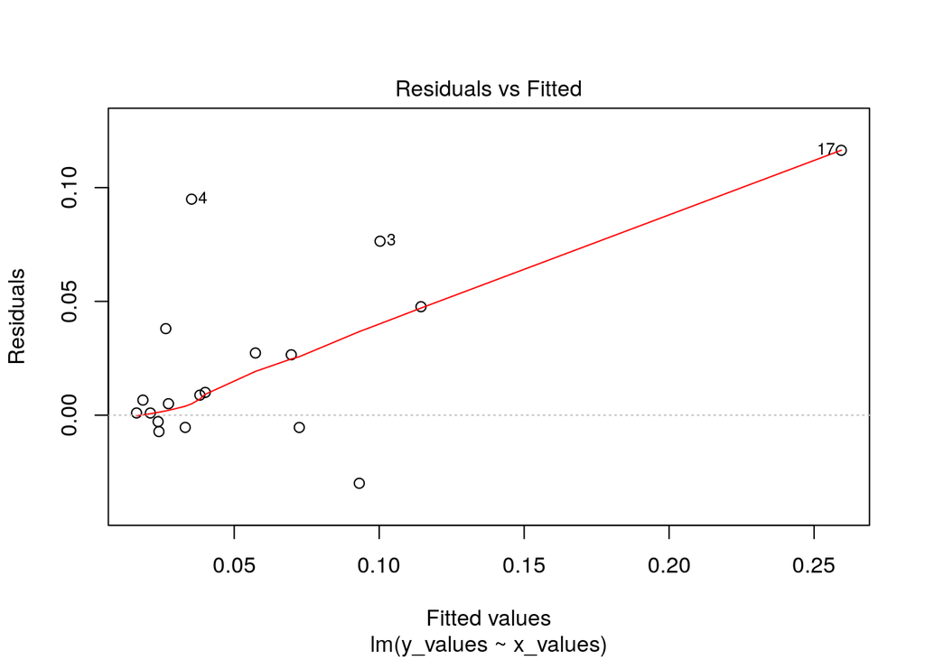

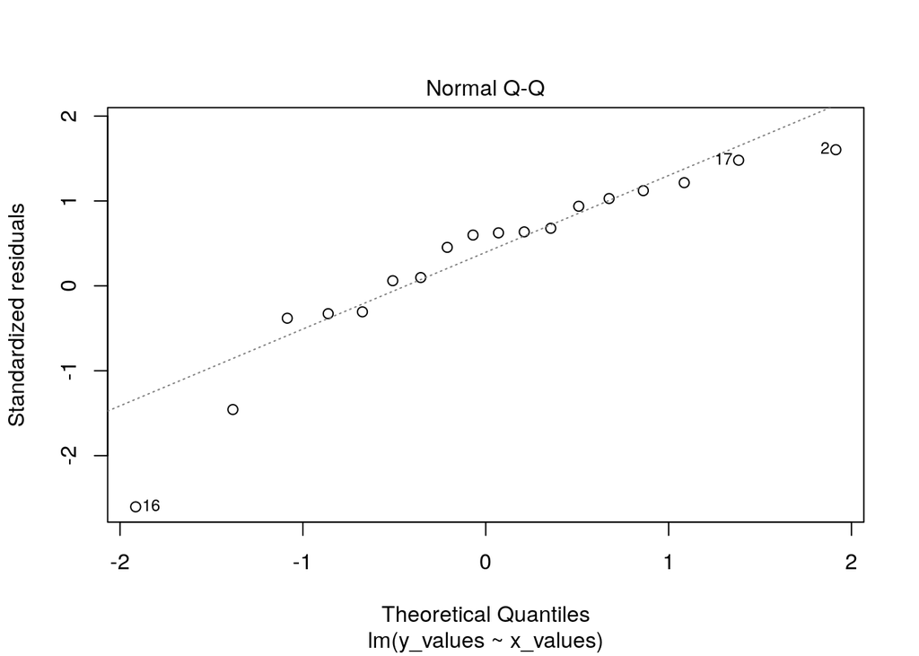

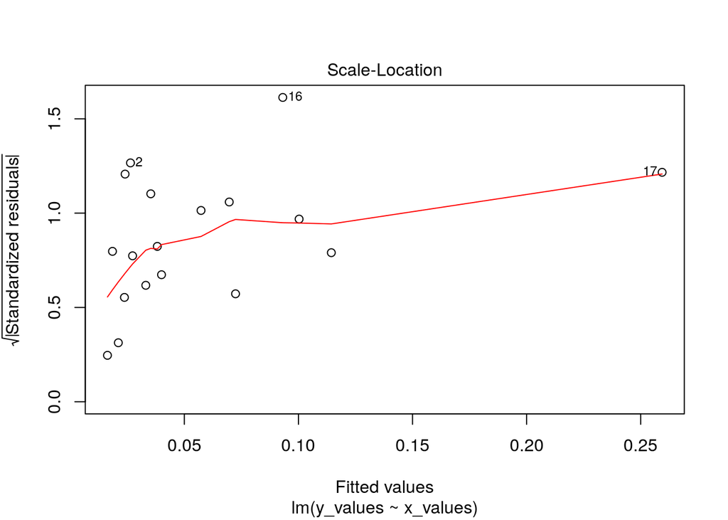

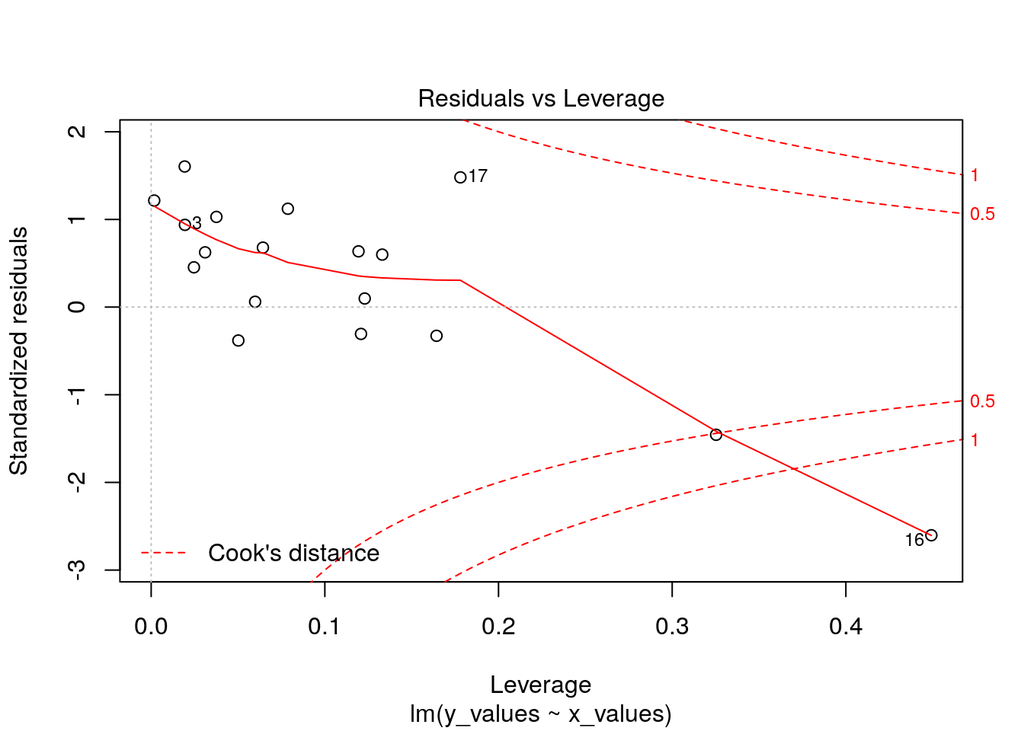

## Reduced major axis regression

### Syntax

```r
model <-lmodel2(y~x, data = dataframe, range.y = "interval",
                 range.x = "interval", nperm = 100)
```

Arguments:

- `formula` - A formula specifying the bivariate model, as in lm.
- `data` - A data frame containing the two variables specified in the formula.
- `range.y`, `range.x` - Parameters for ranged major axis regression (RMA). If range.y = NULL and range.x = NULL, RMA will not be computed. If only one of them is NULL, the program will stop. If range.y = “relative”: variable y has a true zero (relative-scale variable). If range.y = “interval”: variable y possibly includes negative values (interval-scale variable). If range.x = “relative”: variable x has a true zero (relative-scale variable). If range.x = “interval”: variable x possibly includes negative values (interval-scale variable)
- `nperm` - Number of permutations for the tests. If nperm = 0, tests will not be computed.

Here we again use the `anscombe1` data frame:

```r
library(lmodel2) # make sure that this library is loaded in order to use the function below
model <-lmodel2(y~x, data = anscombe1, range.y = "interval",
                 range.x = "interval", nperm = 100)
```

From the regression results, we want to retrieve the `Intercept` and `Slope` values for the RMA method. Below we can see the results that we have to search through.

```r
model$regression.results
```

```
##   Method Intercept     Slope Angle (degrees) P-perm (1-tailed)
## 1    OLS  3.000091 0.5000909        26.56922        0.00990099
## 2     MA  2.511327 0.5543980        29.00390        0.00990099
## 3    SMA  1.988042 0.6125408        31.48917                NA
## 4    RMA  2.075872 0.6027819        31.08081        0.00990099
```

There are two ways in which you can extract these values. First, since `model$regression.results` is a data frame (which you can check by typing `class(model$regression.results)`), you can use indices to directly extract data from a cell at a specific row and column number:

```r
intercept <- model$regression.results[4,2]
slope <- model$regression.results[4,3]
```

Another way is to use `dplyr` as discussed in the previous practical. Here we `filter` the data frame `model$regression.results` for all rows where `Method == "RMA"`, and then we `select` the value in the `Intercept` column. This will give us a data frame with only one row and one column. Since we want the number in the data frame, and not the data frame itself, we need to add the extra step of `%>% unlist()`.

```r
intercept = model$regression.results %>% filter(Method == "RMA") %>% select(Intercept) %>% unlist()
slope = model$regression.results %>% filter(Method == "RMA") %>% select(Slope) %>% unlist()
```

Make a summary of the regression model:

```r
summary(model)
```

```
##                      Length Class      Mode
## y                    11     -none-     numeric
## x                    11     -none-     numeric
## regression.results    5     data.frame list
## confidence.intervals  5     data.frame list
## eigenvalues           2     -none-     numeric
## H                     1     -none-     numeric
## n                     1     -none-     numeric
## r                     1     -none-     numeric
## rsquare               1     -none-     numeric
## P.param               1     -none-     numeric
## theta                 1     -none-     numeric
## nperm                 1     -none-     numeric
## epsilon               1     -none-     numeric
## info.slope            1     -none-     numeric
## info.CI               1     -none-     numeric
## call                  6     -none-     call
```

Plot the results of the regression model:

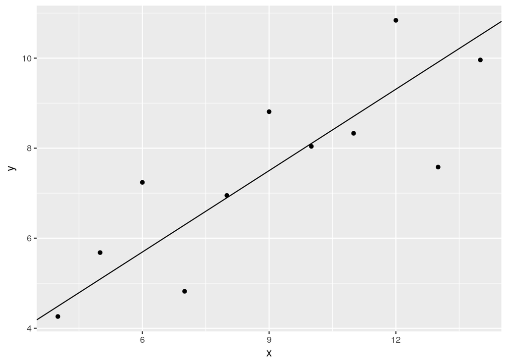

```r
ggplot(anscombe1, aes(x=x, y=y)) + geom_point() + geom_abline(slope=slope, intercept=intercept)
```

### Exercise

Make a reduced major axis regression for x and y in the `Practical6_data.txt` and add the regression line to the plot

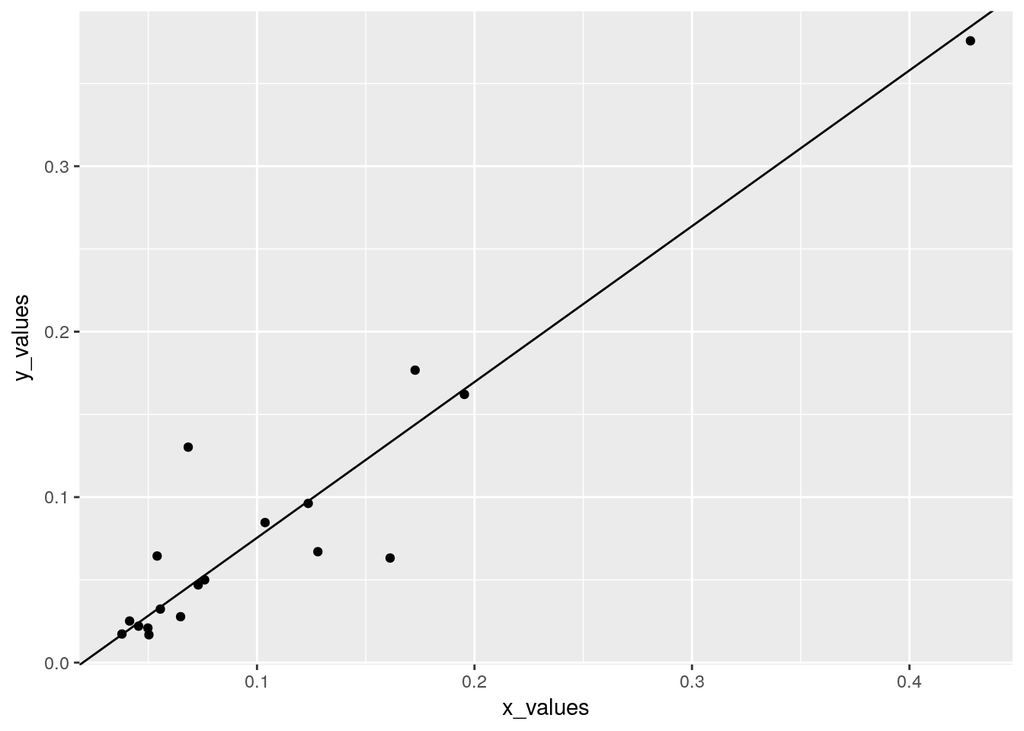

```
##                      Length Class      Mode
## y                    18     -none-     numeric
## x                    18     -none-     numeric
## regression.results    5     data.frame list
## confidence.intervals  5     data.frame list
## eigenvalues           2     -none-     numeric
## H                     1     -none-     numeric
## n                     1     -none-     numeric
## r                     1     -none-     numeric
## rsquare               1     -none-     numeric
## P.param               1     -none-     numeric
## theta                 1     -none-     numeric
## nperm                 1     -none-     numeric
## epsilon               1     -none-     numeric
## info.slope            1     -none-     numeric
## info.CI               1     -none-     numeric
## call                  6     -none-     call
```

## Multiple regression

### Reminder of the lecture 9

$Y_i = \beta_0 + \beta_1*X_{1i} + \beta_2*X_{2i} + \beta_3*X_{3i} + … + \epsilon_i$

Interpretation of the parameters:

- If $\beta_j > 0$, then $j$ stands for the average increase of the response when predictor $x_j$ increases with one unit, holding all other variables constant.
- If $\beta_j < 0$, then $j$ stands for the average decrease of the response when predictor $x_j$ increases with one unit, holding all other variables constant.

An anova test can be done to see if the removing one variable significantly changes the fit. If p-value of the anova test <0.05, you should keep the variable (as a rule of thumb)

### Syntax

#### Linear model as a function of several parameters

say you have several variables (y, x1, x2, x3, …) in the data frame `dat`

```r
z = lm(y~ x1 + x2 + x3 + …, data = dat)
```

#### A pairs plot

A pairs plot is useful for doing an initial exploration of how different variables (i.e. columns in a data frame) may be related to each other. A pairs plot is presented as a matrix containing scatter plots of all the combinations of variables with each other.

To be able to do this, make sure to install and load the `GGally` library as described above.

```r
install.packages("GGally")
library(GGally)
```

As an example, we’ll use a pairs plot on the `mtcars` dataset. For this, we only use the `mpg`, `disp`, `hp` and `qsec` columns. Looking at the first few rows in these columns, we see:

```r
head(mtcars[,c("mpg", "disp", "hp", "qsec")])
```

```
##                    mpg disp  hp  qsec
## Mazda RX4         21.0  160 110 16.46
## Mazda RX4 Wag     21.0  160 110 17.02
## Datsun 710        22.8  108  93 18.61
## Hornet 4 Drive    21.4  258 110 19.44
## Hornet Sportabout 18.7  360 175 17.02
## Valiant           18.1  225 105 20.22
```

The pairs plot for these four columns looks like this:

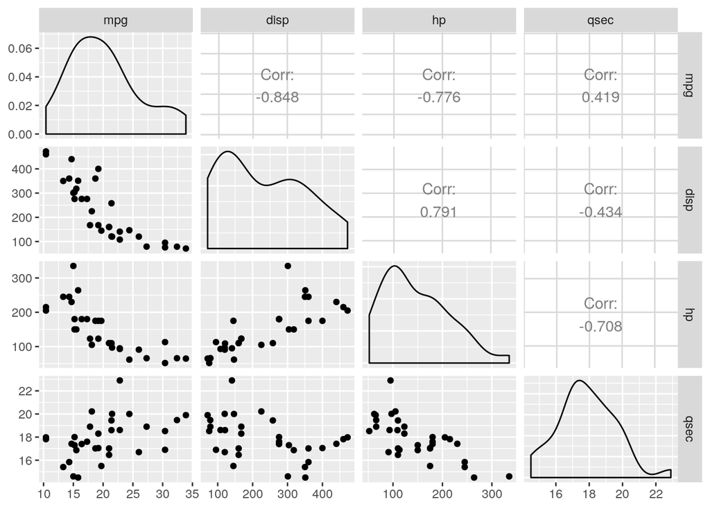

```r
ggpairs(mtcars[,c("mpg", "disp", "hp", "qsec")])
```

Reading across the rows and columns we can see which variables are being plotted together. In the first column and second row, we have the `disp` vs. the `mpg`, directly below that is the `hp` vs. the `mpg` and so on. On the top right we can see the correlations calculated between the variables. On the diagonal we see a density plot of the variables. For example, most of the values for `hp` are around 100, although the distribution is skewed to one side.

Now we perform a linear regression where we try to predict `mpg` given the values for `disp`, `hp` and `qsec`

```r
z = lm(mpg~disp + hp + qsec, data=mtcars)
summary(z)
```

```
##
## Call:
## lm(formula = mpg ~ disp + hp + qsec, data = mtcars)
##
## Residuals:
##     Min      1Q  Median      3Q     Max
## -4.5029 -2.6417 -0.6002  1.9749  7.2263
##
## Coefficients:
##              Estimate Std. Error t value Pr(>|t|)
## (Intercept) 38.622206   9.668300   3.995 0.000426 ***
## disp        -0.028468   0.007787  -3.656 0.001049 **
## hp          -0.034642   0.017967  -1.928 0.064041 .
## qsec        -0.385561   0.468127  -0.824 0.417114
## ---
## Signif. codes:  0 '***' 0.001 '**' 0.01 '*' 0.05 '.' 0.1 ' ' 1
##
## Residual standard error: 3.144 on 28 degrees of freedom
## Multiple R-squared:  0.7542, Adjusted R-squared:  0.7279
## F-statistic: 28.64 on 3 and 28 DF,  p-value: 1.118e-08
```

We can also extract the $R^2$ value from the summary:

```r
summary_for_z <- summary(z)
print(summary_for_z$r.squared)
```

```
## [1] 0.7541953
```

Create a series of diagnostic plots:

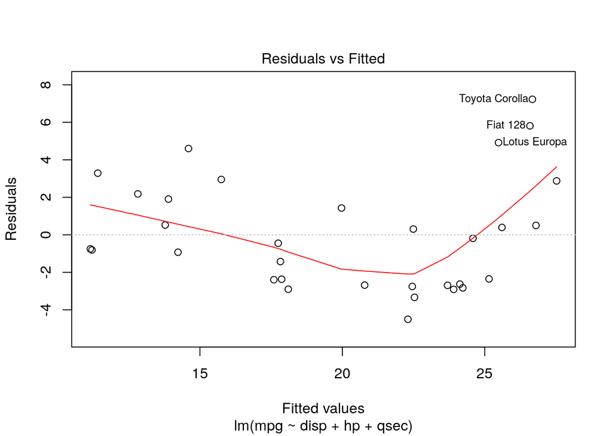

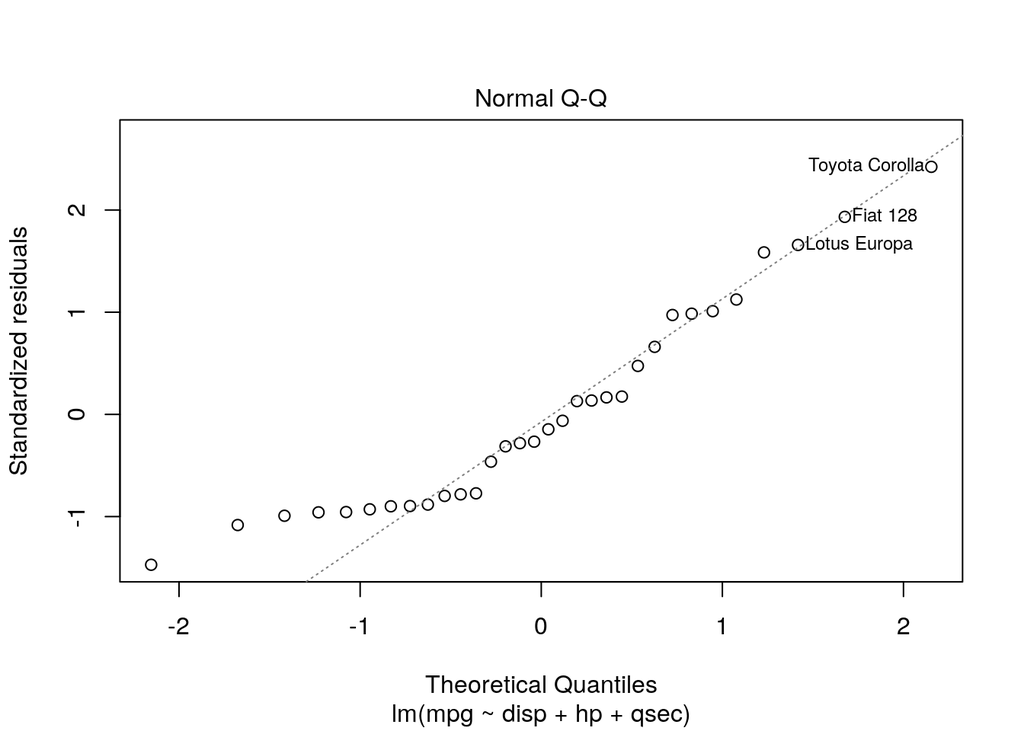

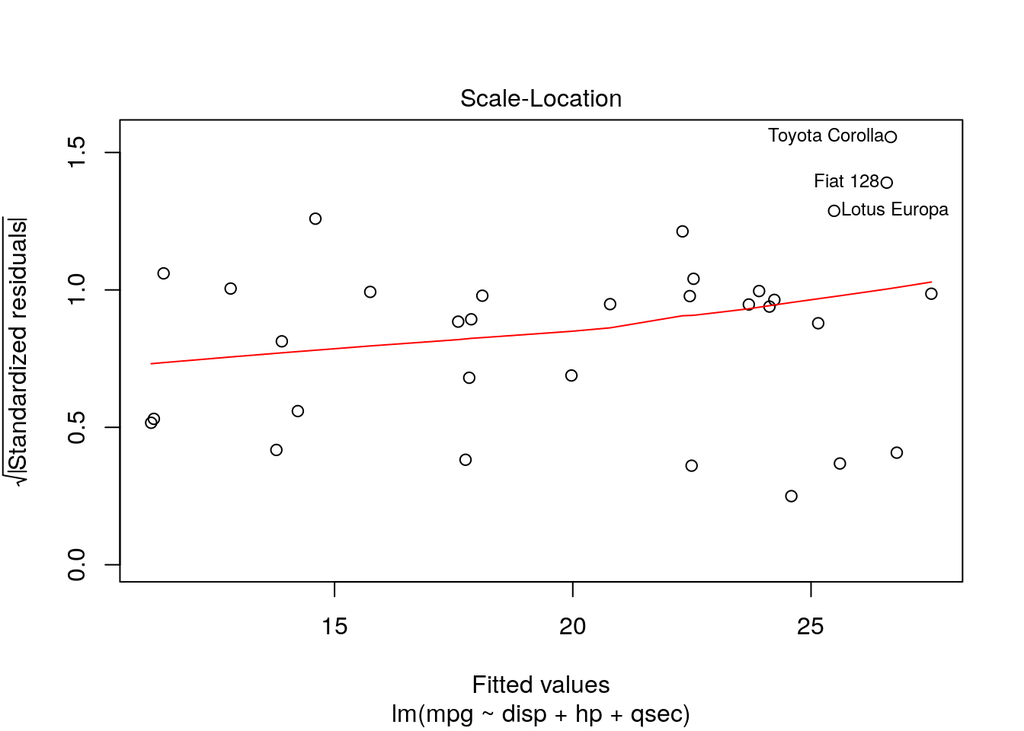

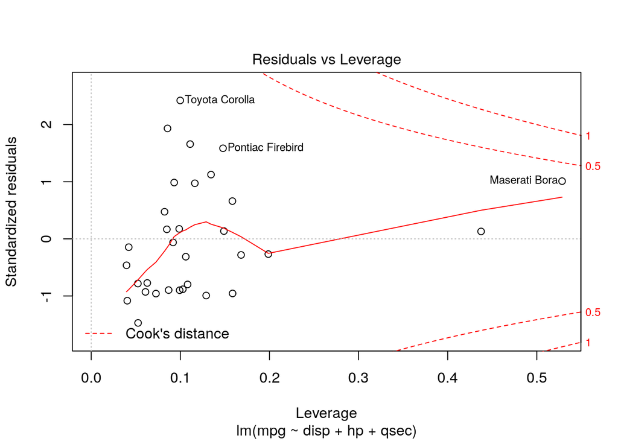

```r
plot(z)
```

#### Anova test

We can perform an Anova test using the following set up (assuming a data frame named `dat` with columns named `y`, `x1`, `x2`, and `x3`)

- `z1 = lm(y~ x1 + x2 + x3, data = dat)`
- `z2 = lm(y~ x1 + x2, data = dat)`
- `anova(z1,z2)`

Using the `mtcars` example, we can do:

```r
z1 = lm(mpg~disp + hp + qsec, data=mtcars)
z2 = lm(mpg~disp + hp, data=mtcars)  # leave out `qsec`
results = anova(z1, z2)
print(results)
```

```
## Analysis of Variance Table
##
## Model 1: mpg ~ disp + hp + qsec
## Model 2: mpg ~ disp + hp
##   Res.Df    RSS Df Sum of Sq      F Pr(>F)
## 1     28 276.79
## 2     29 283.49 -1   -6.7057 0.6784 0.4171
```

### Exercise

For this we’ll use the `stackloss` data set with was mentioned in Lecture 8. This data frame is already pre-loaded with R, and you can get more details about it by typing `?stackloss` in the console.

#### Look at a summary of the data set

```
##     Air.Flow       Water.Temp     Acid.Conc.      stack.loss
##  Min.   :50.00   Min.   :17.0   Min.   :72.00   Min.   : 7.00
##  1st Qu.:56.00   1st Qu.:18.0   1st Qu.:82.00   1st Qu.:11.00
##  Median :58.00   Median :20.0   Median :87.00   Median :15.00
##  Mean   :60.43   Mean   :21.1   Mean   :86.29   Mean   :17.52
##  3rd Qu.:62.00   3rd Qu.:24.0   3rd Qu.:89.00   3rd Qu.:19.00
##  Max.   :80.00   Max.   :27.0   Max.   :93.00   Max.   :42.00
```

#### Make a pairs plot

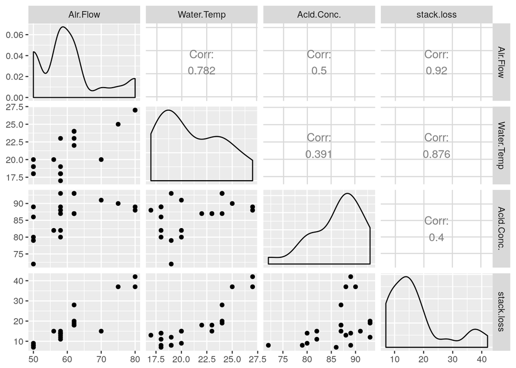

#### Fit a linear model using all variables and summarize the output of the model

For this we are trying to predict `stack.loss` given all the other variables

```
##
## Call:
## lm(formula = stack.loss ~ Acid.Conc. + Air.Flow + Water.Temp,
##     data = stackloss)
##
## Residuals:
##     Min      1Q  Median      3Q     Max
## -7.2377 -1.7117 -0.4551  2.3614  5.6978
##
## Coefficients:
##             Estimate Std. Error t value Pr(>|t|)
## (Intercept) -39.9197    11.8960  -3.356  0.00375 **
## Acid.Conc.   -0.1521     0.1563  -0.973  0.34405
## Air.Flow      0.7156     0.1349   5.307  5.8e-05 ***
## Water.Temp    1.2953     0.3680   3.520  0.00263 **
## ---
## Signif. codes:  0 '***' 0.001 '**' 0.01 '*' 0.05 '.' 0.1 ' ' 1
##
## Residual standard error: 3.243 on 17 degrees of freedom
## Multiple R-squared:  0.9136, Adjusted R-squared:  0.8983
## F-statistic:  59.9 on 3 and 17 DF,  p-value: 3.016e-09
```

#### Plot the standard diagnostic plots

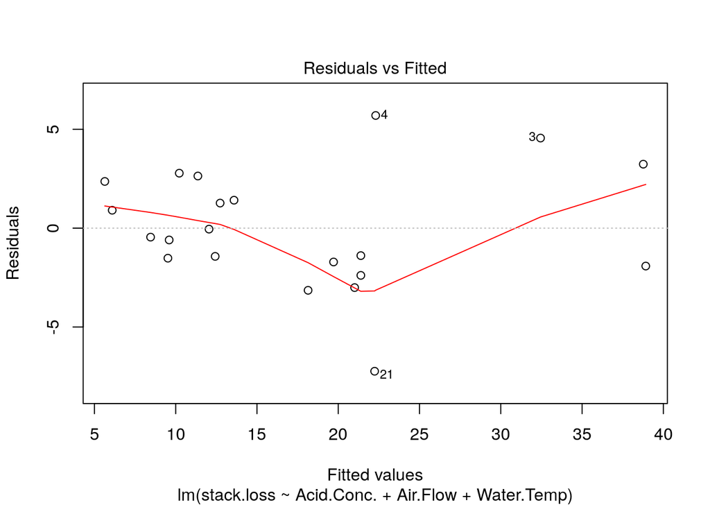

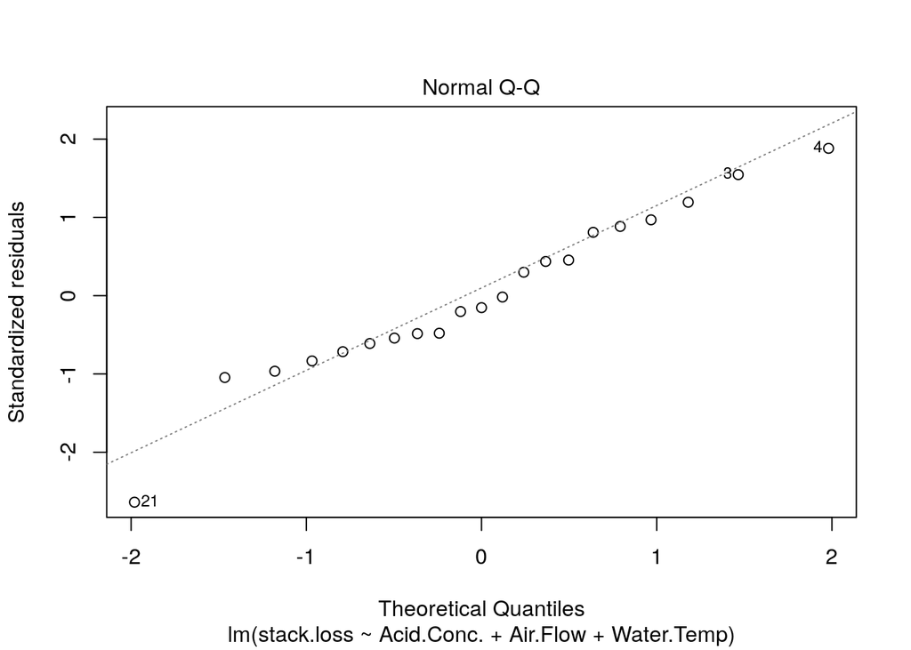

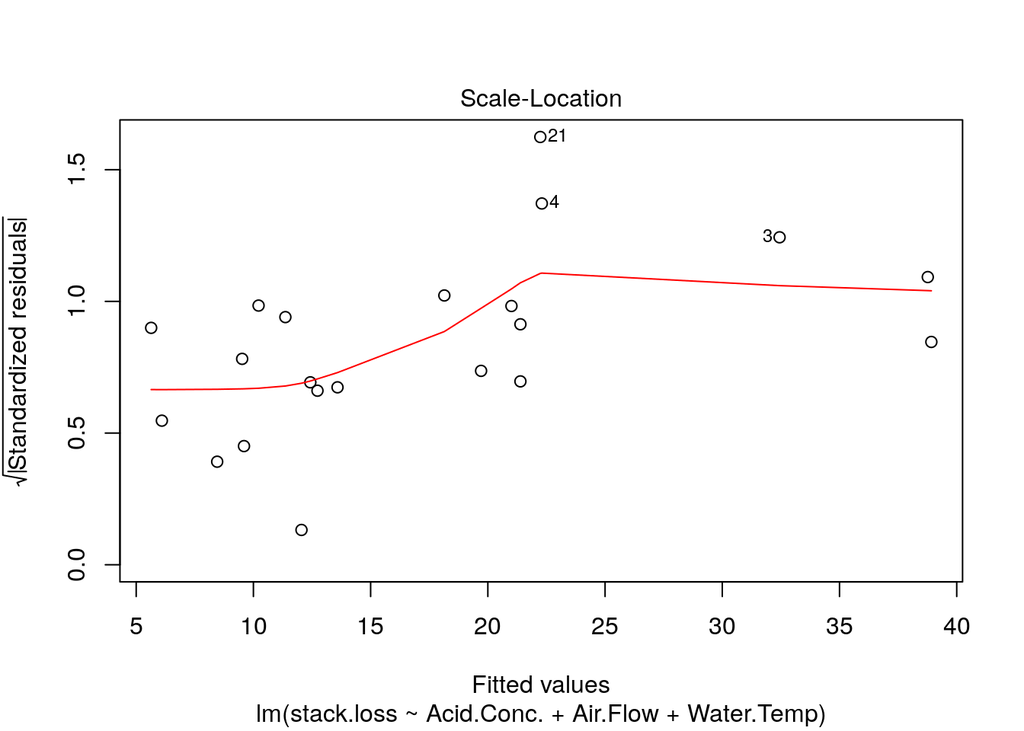

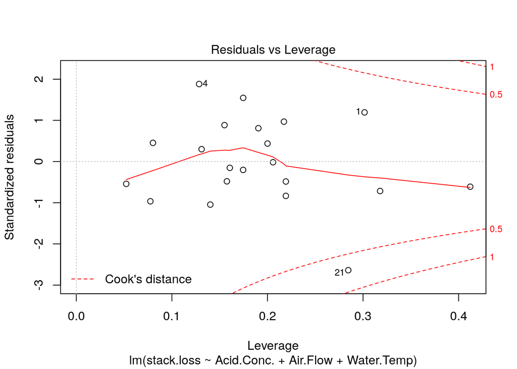

#### Make a Cook’s distance plot by hand with a cutoff line

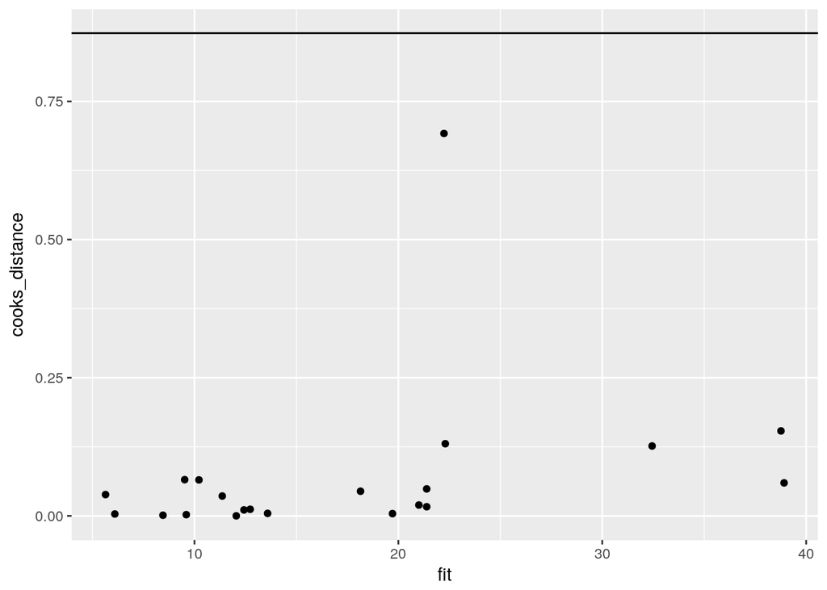

#### Leave out the least important parameter Acid concentration

```
##
## Call:
## lm(formula = stack.loss ~ Air.Flow + Water.Temp, data = stackloss)
##
## Residuals:
##     Min      1Q  Median      3Q     Max
## -7.5290 -1.7505  0.1894  2.1156  5.6588
##
## Coefficients:
##             Estimate Std. Error t value Pr(>|t|)
## (Intercept) -50.3588     5.1383  -9.801 1.22e-08 ***
## Air.Flow      0.6712     0.1267   5.298 4.90e-05 ***
## Water.Temp    1.2954     0.3675   3.525  0.00242 **
## ---
## Signif. codes:  0 '***' 0.001 '**' 0.01 '*' 0.05 '.' 0.1 ' ' 1
##
## Residual standard error: 3.239 on 18 degrees of freedom
## Multiple R-squared:  0.9088, Adjusted R-squared:  0.8986
## F-statistic: 89.64 on 2 and 18 DF,  p-value: 4.382e-10
```

#### See if that made a difference for the overall model

```
## Analysis of Variance Table
##
## Model 1: stack.loss ~ Acid.Conc. + Air.Flow + Water.Temp
## Model 2: stack.loss ~ Air.Flow + Water.Temp
##   Res.Df    RSS Df Sum of Sq      F Pr(>F)
## 1     17 178.83
## 2     18 188.79 -1   -9.9654 0.9473  0.344
```

#### Now leave out water temp

```
##
## Call:
## lm(formula = stack.loss ~ Air.Flow, data = stackloss)
##
## Residuals:
##      Min       1Q   Median       3Q      Max
## -12.2896  -1.1272  -0.0459   1.1166   8.8728
##
## Coefficients:
##              Estimate Std. Error t value Pr(>|t|)
## (Intercept) -44.13202    6.10586  -7.228 7.31e-07 ***
## Air.Flow      1.02031    0.09995  10.208 3.77e-09 ***
## ---
## Signif. codes:  0 '***' 0.001 '**' 0.01 '*' 0.05 '.' 0.1 ' ' 1
##
## Residual standard error: 4.098 on 19 degrees of freedom
## Multiple R-squared:  0.8458, Adjusted R-squared:  0.8377
## F-statistic: 104.2 on 1 and 19 DF,  p-value: 3.774e-09
```

Perform the anova test:

```
## Analysis of Variance Table
##
## Model 1: stack.loss ~ Air.Flow + Water.Temp
## Model 2: stack.loss ~ Air.Flow
##   Res.Df    RSS Df Sum of Sq      F   Pr(>F)
## 1     18 188.80
## 2     19 319.12 -1   -130.32 12.425 0.002419 **
## ---
## Signif. codes:  0 '***' 0.001 '**' 0.01 '*' 0.05 '.' 0.1 ' ' 1
```

#### Fits of individual varaibles

For this create a set of linear regressions for combinations of the individual variables

##### Regression for `stack.loss~Air.Flow`

Value for $R^{2}$:

```
## [1] 0.8457809
```

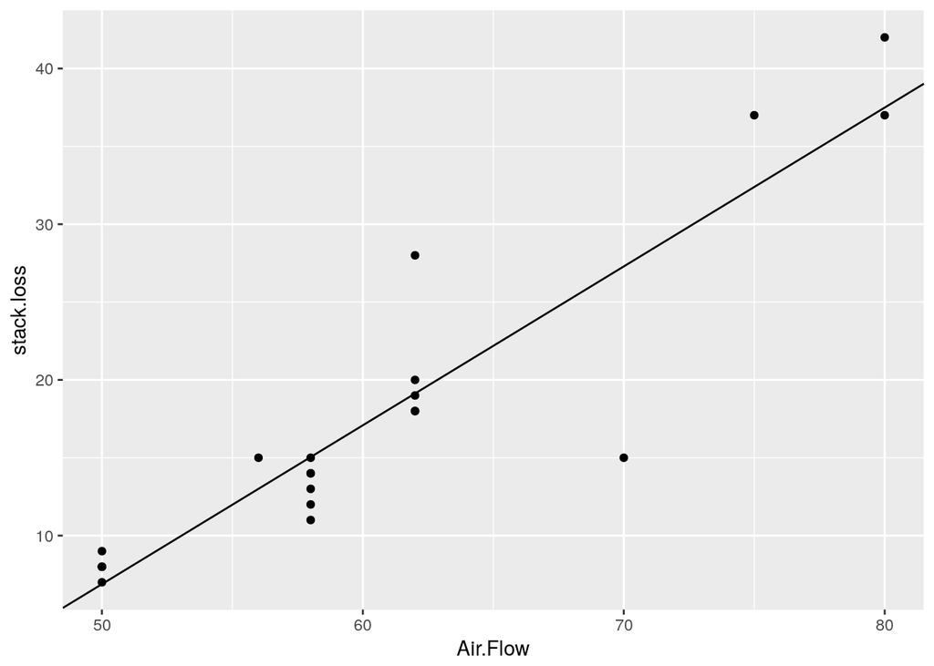

##### Regression for `stack.loss~Water.Temp`

Value for $R^{2}$:

```
## [1] 0.766508
```

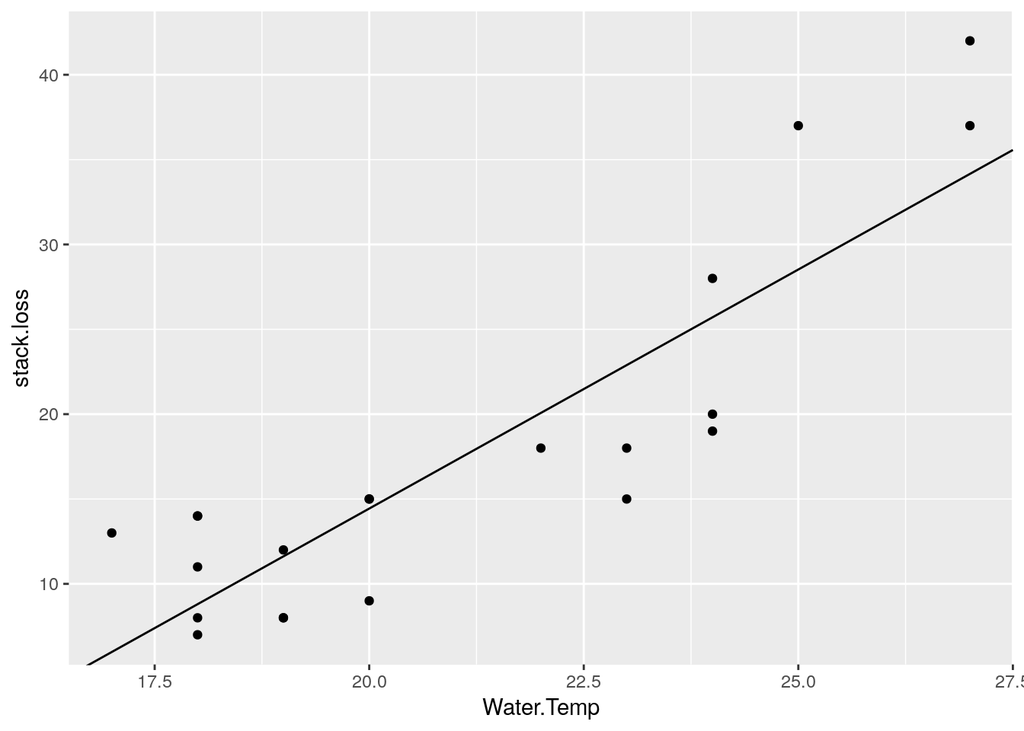

##### Regression for `Air.Flow~Water.Temp`

Value for $R^{2}$:

```
## [1] 0.6112931
```

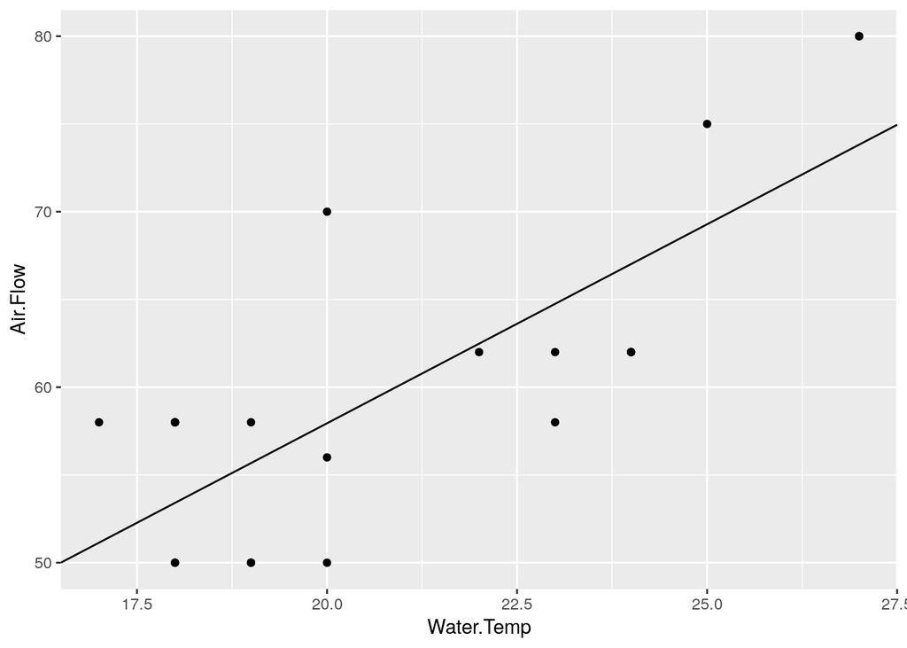

## Replacing values with NA

Regarding `NA` values:

- If you are doing a numeric comparisons (i.e. `hp >= 250`) using the `filter` function, then `NA` values will be filtered out.
- If you want to do a numeric comparison and also keep `NA` values, then you need to specify something like `hp >= 250 | is.na(hp)`. The function `is.na()` will return `TRUE` for any `NA` values.

Real data may often have missing values, which are represented in R as `NA`. In some data sets you may see them represented in other forms like `NaN` (not a number) or by an unrealistic number (e.g., -999). For R to handle the missing values, you have to rename them as `NA`, if they are not named like that, then R does not recognize them and will try to process them as an actual number.

Let’s say that for a data frame we have called `df`, `NA` values are currently represented as `-999`. If we type into the console `df == -999`, we’ll get a matrix of `TRUE`, `FALSE` or `NA` values (if `NA` is already present).

To replace these -999 values, we use the command below which says that for all locations in the data frame with a value of -999, we should assign to those locations the value `NA` instead.

```r
df[df == -999] <-NA
```

### Exercise 1

For this exercise, download the Carbon.csv data into R as a data frame called `input1`.

After loading in the csv file into R, try to replace the -999 values with `NA`. If you run `summary` before the replacement you should see:

```
##           date_start elementary.carbon.from.fossil.fuels     BB_EC
##  01/03/12 12:35: 1   Min.   :0.1077                      Min.   :0.01385
##  01/06/11 13:30: 1   1st Qu.:0.2289                      1st Qu.:0.02643
##  02/05/11 15:15: 1   Median :0.3446                      Median :0.06442
##  02/12/11 09:15: 1   Mean   :0.5839                      Mean   :0.12673
##  06/06/11 11:45: 1   3rd Qu.:0.6550                      3rd Qu.:0.14614
##  07/07/11 13:30: 1   Max.   :2.2389                      Max.   :0.66726
##  (Other)       :17
##      FF_OC               BB_OC               BIO_OC
##  Min.   :-999.0000   Min.   :-999.0000   Min.   :0.2535
##  1st Qu.:   0.2770   1st Qu.:   0.1179   1st Qu.:0.4915
##  Median :   0.4028   Median :   0.3220   Median :0.7457
##  Mean   : -42.8049   Mean   : -42.8112   Mean   :1.1032
##  3rd Qu.:   0.5454   3rd Qu.:   0.7306   3rd Qu.:1.2399
##  Max.   :   2.2815   Max.   :   3.3353   Max.   :4.0950
##
##     FF_WIOC              C_WIOC           FF_WSOC
##  Min.   :-999.0000   Min.   :0.04875   Min.   :-0.16657
##  1st Qu.:   0.1436   1st Qu.:0.12869   1st Qu.: 0.09897
##  Median :   0.1950   Median :0.26482   Median : 0.17624
##  Mean   : -86.5462   Mean   :0.42041   Mean   : 0.28935
##  3rd Qu.:   0.3089   3rd Qu.:0.42538   3rd Qu.: 0.35644
##  Max.   :   1.4266   Max.   :1.80312   Max.   : 1.05329
##
##      C_WSOC
##  Min.   :-999.0000
##  1st Qu.:   0.4852
##  Median :   0.8561
##  Mean   : -42.1394
##  3rd Qu.:   1.5079
##  Max.   :   4.2263
##
```

After replacing them, using `summary` you should see that several columns now have `NA` values:

```
##           date_start elementary.carbon.from.fossil.fuels     BB_EC
##  01/03/12 12:35: 1   Min.   :0.1077                      Min.   :0.01385
##  01/06/11 13:30: 1   1st Qu.:0.2289                      1st Qu.:0.02643
##  02/05/11 15:15: 1   Median :0.3446                      Median :0.06442
##  02/12/11 09:15: 1   Mean   :0.5839                      Mean   :0.12673
##  06/06/11 11:45: 1   3rd Qu.:0.6550                      3rd Qu.:0.14614
##  07/07/11 13:30: 1   Max.   :2.2389                      Max.   :0.66726
##  (Other)       :17
##      FF_OC            BB_OC             BIO_OC          FF_WIOC
##  Min.   :0.1173   Min.   :0.06923   Min.   :0.2535   Min.   :0.08086
##  1st Qu.:0.2867   1st Qu.:0.12886   1st Qu.:0.4915   1st Qu.:0.17058
##  Median :0.4328   Median :0.32871   Median :0.7457   Median :0.19604
##  Mean   :0.6585   Mean   :0.65190   Mean   :1.1032   Mean   :0.35414
##  3rd Qu.:0.5580   3rd Qu.:0.77068   3rd Qu.:1.2399   3rd Qu.:0.31171
##  Max.   :2.2815   Max.   :3.33533   Max.   :4.0950   Max.   :1.42661
##  NA's   :1        NA's   :1                          NA's   :2
##      C_WIOC           FF_WSOC             C_WSOC
##  Min.   :0.04875   Min.   :-0.16657   Min.   :0.2886
##  1st Qu.:0.12869   1st Qu.: 0.09897   1st Qu.:0.5394
##  Median :0.26482   Median : 0.17624   Median :0.8566
##  Mean   :0.42041   Mean   : 0.28935   Mean   :1.3542
##  3rd Qu.:0.42538   3rd Qu.: 0.35644   3rd Qu.:1.5549
##  Max.   :1.80312   Max.   : 1.05329   Max.   :4.2263
##                                       NA's   :1
```